# REGLAS DE ASOCIACIÓN

Vamos a aplicar reglas de aociación a la tabla de transacciones en el que se tiene una línea por cada alquiler con el id de la máquina.

```python
import numpy as np
import matplotlib.pyplot as plt
import pandas as pd
from mlxtend.preprocessing import TransactionEncoder
from mlxtend.frequent_patterns import apriori, association_rules
```

### Cargamos los datos

Vamos a necesitar:

1. El listado de transacciones con las lineas de las facturas de venta en la que vienen el IdArticulo, Precio, IdCliente
2. El resultado de la clasificación de clientes en el que vienen el IdCliente, Cluster
3. El listado de artículos en el que viene IdArticulo, Descripción para poder agrupar y analizar si es necesario en familias de artículos.

```python
from google.colab import drive
drive.mount('/content/drive')
```

```python
df_lineas_venta = pd.read_csv (r'/content/drive/MyDrive/BBDD/LINEAS DE VENTA POR CONTRATO Y CLIENTE v2.csv')
```

```python
df_contratos_lineas = pd.read_csv("/content/drive/MyDrive/BBDD/vista_contratos_lineas_ampliado.csv",  sep='{', header='infer')
df_contratos_lineas.head(5)
```

|  | Marca | IdContrato | IdArticulo | Descrip | TipoAlquiler | Precio_Euros | FechaInicio | HoraInicio | FechaPrevistaFin | HoraPrevistaFin | ... | ContadorInicial | ContadorActual | TipoAlquiler_Descrip | IdEmpresa | IdCliente | Cliente | Planta | Delegacion | FechaFactura | Nif |
| --- | --- | --- | --- | --- | --- | --- | --- | --- | --- | --- | --- | --- | --- | --- | --- | --- | --- | --- | --- | --- | --- |
| 0 | 0 | 530 | 02509D1601 | ASTILLADORA HIDRAULICA PARA LEÑA 12 TN.Nº1601 | 2 | 55 | 2020-01-02 00:00:00.000 | 08:14 | NaN | NaN | ... | 410 | 450 | Diario | 0 | 438 | INDUSTRIAS XOVE, S.A. | ALCOA - SAN CIPRIAN (CERVO) | RM XOVE | 2020-01-15 00:00:00.000 | A27112317 |
| 1 | 0 | 530 | 09900000GR | GESTION DE RESIDUOS 1% | 2 | 0,55 | 2020-01-02 00:00:00.000 | 08:14 | NaN | NaN | ... | 0 | 0 | Diario | 0 | 438 | INDUSTRIAS XOVE, S.A. | ALCOA - SAN CIPRIAN (CERVO) | RM XOVE | 2020-01-15 00:00:00.000 | A27112317 |
| 2 | 0 | 531 | 01902D1802 | MINIRRETRO HITACHI ZX19 Nº1802 | 2 | 81 | 2020-01-02 00:00:00.000 | 08:19 | NaN | NaN | ... | 509 | 608 | Diario | 0 | 680 | TECNICAS CONSTRUCCION SEVEMUL S.L | IGLESIA DE OTERO | RM PONFERRADA | 2020-01-20 00:00:00.000 | B24673832 |
| 3 | 0 | 531 | 01900A0001 | ENGRASADORA MANUAL GRASA BISULFURO (azul) | 2 | 0 | 2020-01-02 00:00:00.000 | 08:19 | NaN | NaN | ... | 0 | 0 | Diario | 0 | 680 | TECNICAS CONSTRUCCION SEVEMUL S.L | IGLESIA DE OTERO | RM PONFERRADA | 2020-01-20 00:00:00.000 | B24673832 |
| 4 | 0 | 531 | 01902A1801 | CAZO DE 300mm. HITACHI ZX19 | 2 | 0 | 2020-01-02 00:00:00.000 | 08:19 | NaN | NaN | ... | 0 | 0 | Diario | 0 | 680 | TECNICAS CONSTRUCCION SEVEMUL S.L | IGLESIA DE OTERO | RM PONFERRADA | 2020-01-20 00:00:00.000 | B24673832 |

5 rows × 25 columns

```python
df_Rilo_Clientes = pd.read_csv("/content/drive/MyDrive/BBDD/merge_clientes_cesce_ventas_classification.csv",  sep=',', header='infer')
df_clientes_id_nif = df_Rilo_Clientes[['Nif', 'IDCliente']]
df_clientes_id_nif.head(3)
```

|  | Nif | IDCliente |
| --- | --- | --- |
| 0 | U27869056 | 80002 |
| 1 | B15057474 | 110007 |
| 2 | B15399314 | 120003 |

```python
df_clasificacion_clientes = pd.read_csv("/content/drive/MyDrive/Colab Notebooks/Clasificador/Clasificación_Clientes_MERGE.csv", header='infer')
df_clientes_id_nif_cluster = pd.merge(df_clientes_id_nif, df_clasificacion_clientes[['IDCliente', 'cluster']], left_on='IDCliente', right_on='IDCliente', how='left')
df_clientes_id_nif_cluster.head(3)
```

|  | Nif | IDCliente | cluster |
| --- | --- | --- | --- |
| 0 | U27869056 | 80002 | NaN |
| 1 | B15057474 | 110007 | 3.0 |
| 2 | B15399314 | 120003 | NaN |

Vemos que hay algunos clientes que no tiene cluster asignado. PAra esos clientes asignamos el cluster 6

Necesitamos utilizar el IdCliente como clave para cruzar los datos de diferentes dataframe

```python
df_contratos_lineas = pd.merge(df_contratos_lineas, df_clientes_id_nif_cluster, right_on='Nif', left_on='Nif', how='left').drop('IdCliente', axis=1)
```

Vamos a quedarnos con los campos que nos interesan para el recomendador. Al tratarse de las líneas de compra lo que nos interesa es un identificador de cliente y el artículo.

```python
df_contratos_lineas_mini = df_contratos_lineas[['IDCliente', 'cluster', 'IdArticulo', 'IdContrato', 'Precio_Euros']]
df_contratos_lineas_mini['Precio_Euros'] = df_contratos_lineas_mini['Precio_Euros'].str.replace(',','.').astype(float)
```

Quitamos las lineas que tienen precio negatio o 0 que son o devoluciones o artículos que se regalan (normalmente porque son componentes de un pack y alquilando uno se incluyen otros con precio 0)

```python
df_contratos_lineas_valor = df_contratos_lineas_mini.loc[df_contratos_lineas_mini.Precio_Euros>0]
```

Ahora vamos a ver si podemos agrupar por artículos y limpiar más transacciones que no aportan.

```python
df_articulos = pd.read_csv('/content/drive/MyDrive/BBDD/articulos.csv', delimiter='{')
df_articulos.head(3)
```

|  | IdArticulo | IdNivel | Descrip | Notas | TipoCantidad | CantidadBulto | Tipo | PeriodoGarantia | UnidadesGarantia | CodBarras | ... | SubcuentaVentaExtranjero | SubcuentaAbonoExtranjero | IdOpServicios | NumLoteGenerico | SWIN_FactorConversion | SWIN_UnidadesXCaja | IdDoc | InsertUpdate | Usuario | FechaInsertUpdate |
| --- | --- | --- | --- | --- | --- | --- | --- | --- | --- | --- | --- | --- | --- | --- | --- | --- | --- | --- | --- | --- | --- |
| 0 | 0 | 0.0 | (GENERICO) | NaN | Ud | 1.0 | NaN | 0.0 | NaN | NaN | ... | NaN | NaN | 1.0 | NaN | 1.0 | NaN | 3884 | 1 | spico | 2021-11-10 17:16:15.410 |
| 1 | 0009999999 | 0.0 | PORTE CAMION SUBCONTRATADO | NaN | Ud | 1.0 | 3 | 0.0 | NaN | NaN | ... | NaN | NaN | NaN | NaN | 1.0 | NaN | 5677 | 0 | dbo | 2019-10-17 11:29:47.250 |
| 2 | 000C010000 | 0.0 | ENTREGA/RECOGIDA CAMION PEQUEÑO | NaN | Ud | 1.0 | 3 | 0.0 | NaN | NaN | ... | NaN | NaN | NaN | NaN | 1.0 | NaN | 5678 | 0 | dbo | 2019-10-17 11:29:47.250 |

3 rows × 102 columns

```python
df_articulos_mini = df_articulos[['IdArticulo', 'Descrip']]
```

Vemos que en la lista de artículos hay muchos que pueden agruparse en familias. Por ejemplo "Portes" o "Cortadora". Para definir las palabras cogeremos la primera palabra del campo Descrip.

```python
df_articulos_mini['Familia'] = df_articulos_mini['Descrip'].str.split().str[0].str.upper()
```

Antes de continuar con el algoritmo a priori vamos a limpiar los artículos que no sean representativos. Analizamos los valores de Familia para identificar algunas que puedan ser borradas. Para ello vamos a ver las familias con más apariciones en la tabla de transacciones.

```python
df_lineas_venta_articulos = pd.merge(df_contratos_lineas_valor, df_articulos_mini, left_on='IdArticulo', right_on='IdArticulo', how='left')
df_lineas_venta_articulos.shape
```

```
(72650, 7)
```

Vamos a agrupar por la columna Familia que nos determinará los valores únicos de esa columna. Y haremos un estudio posterior para limpiar ciertos valores que no tenga sentido analizar. Por ejemplo:

- Los servicios de portes de maquinaria que para cierto tipo de alquileres son obligatorios y por tanto no son una compra voluntaria
- La gestión de residos que tambien es obligatoria
- ...

```python
df_familias = df_lineas_venta_articulos.groupby(['Familia'])['Familia'].count().sort_values(ascending=False).reset_index(name='counts')
```

```python
df_familias.shape
```

```
(205, 2)
```

```python
df_familias.head(3)
```

|  | Familia | counts |
| --- | --- | --- |
| 0 | GESTION | 21664 |
| 1 | SEGURO | 7129 |
| 2 | MARTILLO | 3213 |

Dentro de las familias, las que vamos analizar con más detalle son:

- Todos los C-XXX: que son los portes realizados con camiones
- Gestión: que es la gestión de residuos obligatoria
- Seguro: que es el seguro obligatorio que se añade en cada contratod e cierto tipo de maquinaria pesada
- ALQUILER: un porcentaje obligatorio que se añade en ciertos tipos de contrato
- KIT: hemos agrupado por familia todos lo que comienzan con la palabra Kit para no tener diferencias
- CIMBRA: todos los artículos que contienen la palabra CIMBRA deben ser agrupados

Vemos que los artículos C-XXX son servicios realizados por camiones y que cada uno de los camiones tiene su propio identificador. por lo que los eliminamos porque no aporta valor al análisis.

```python
df_lineas_venta_articulos = df_lineas_venta_articulos[df_lineas_venta_articulos['Descrip'].str.startswith('C-')==False]
```

```python
df_lineas_venta_articulos = df_lineas_venta_articulos[df_lineas_venta_articulos['Descrip'].str.startswith('GESTION')==False]
```

```python
df_lineas_venta_articulos = df_lineas_venta_articulos[df_lineas_venta_articulos['Descrip'].str.startswith('SEGURO')==False]
```

```python
df_lineas_venta_articulos[df_lineas_venta_articulos['Familia']=='ALQUILER'].Descrip
```

```
26            ALQUILER DISCO 400mm. HILTI DC-D C/ mm.
40             ALQUILER DISCO 230mm. GRAL.OBRA C/ mm.
142      ALQUILER DISCO 305mm. HILTI SPX EQD  C/  mm.
195           ALQUILER DISCO 350mm. HORM./ASF. C/ mm.
241           ALQUILER DISCO 400mm. HILTI DC-D C/ mm.
                             ...
72178         ALQUILER DISCO 350mm. HORM./ASF. C/ mm.
72241         ALQUILER DISCO 350mm. HORM./ASF. C/ mm.
72515         ALQUILER DISCO 350mm. HORM./ASF. C/ mm.
72566    ALQUILER DISCO 305mm. HILTI SPX EQD  C/  mm.
72639    ALQUILER DISCO 305mm. HILTI SPX EQD  C/  mm.
Name: Descrip, Length: 833, dtype: object
```

Todos los elementos que contengan la palabra CIMBRA son elementos de CIMBRA y por tanto les asignamos la familia CIMBRA

```python
df_lineas_venta_articulos.loc[df_lineas_venta_articulos['Descrip'].str.contains('CIMBRA'), 'Familia'] = 'CIMBRA'
```

```python
df_lineas_venta_articulos.loc[df_lineas_venta_articulos['Familia']=='ALQUILER', 'Familia'] = 'ALQUILER DISCOS'
```

La familia KIT es la de KIT de LUCES por lo que reemplazamos su valor

```python
df_lineas_venta_articulos.loc[ df_lineas_venta_articulos['Familia']=='KIT', 'Familia'] = 'KIT LUCES BLUE'
```

```python
df_lineas_venta_articulos['cluster'] = df_lineas_venta_articulos['cluster'].fillna(6)
```

```python
df_lineas_venta_articulos.Familia.unique()
```

```
array(['ASTILLADORA', 'MINIEXCAVADORA', 'RODILLO', 'MARTILLO', 'PUNTERO',
       'MOTOSIERRA', 'ASPIRADOR', 'CORTACESPED', 'PORTE', 'TRONZADORA',
       'ALQUILER DISCOS', 'PISON', 'LIJADORA', 'VIBRADOR', 'DISCO',
       'AMOLADORA', 'CONSUMIBLES', 'TALADRO', 'HIDROLIMPIADORA', 'DUMPER',
       'PLATAFORMA', 'CARRETILLA', 'CINCEL', 'PALA', 'TRANSPALETA',
       'PANEL', 'MAQUINA', 'MINICARGADORA', 'CORONA', 'TABLERO', 'RANAS',
       'LLAVE', 'GENERADOR', 'BROCA', 'DESBROZADORA', 'BARREDORA',
       'GUARDACUERPO', 'PLANCHA', 'HORMIGONERA', 'AHOYADOR', 'NIVEL',
       'REGLA', 'POWERTILT', 'PERFORADORA', 'CIMBRA', 'TRIPODE',
       'ALARGADERA', 'CORTADORA', 'VALLA', 'BOMBA', 'ROLLO', 'SEÑAL',
       'PISTOLA', 'BOQUILLA', 'MEZCLADOR', 'ZANJADORA', 'PUNTALES',
       'CALZO', 'DESHUMIDIFICADOR', 'PANELES', 'FRATASADORA', 'CASETA',
       'CAÑON', 'CALEFACTOR', 'CORTASETOS', 'TUBO', 'BOCA', 'PIE',
       'ENCOFRADO', 'ACCESORIOS', 'MASCARILLA', 'MONO', 'JUEGO', 'TORRE',
       'FREGADORA', 'ROZADORA', 'CAZO', 'ALQUILERES', 'CINTA',
       'COMPRESOR', 'BARRERA', 'CHAPA', 'ESTANTERIA', 'MESA', 'SILLA',
       'SIERRA', 'MOTOAZADA', 'APILADOR', 'SACO', 'ENGRASADORA', 'CHAPAS',
       'TROLLEY', 'CONO', 'PODADORA', 'POLIPASTO', 'ANCLAJE', 'CUBO',
       'PINZA', 'ELEVADOR', 'ACOPLE', 'MINIDUMPER', 'PASADORES',
       'KIT LUCES BLUE', 'LITROS', 'CORBATA', 'BARANDILLA', 'SERVICIO',
       'ARENADOR', 'SARGENTOS', 'SOPLADOR/ATOMIZADOR', '-ALQUILERES',
       'GUIAS', 'AFILADO', 'GENERICO', 'BALIZA', 'ATORNILLADOR',
       'CAMILLA', 'DESFIBRILADOR', 'TABLA', 'TAQUILLAS', 'TANQUE',
       'SEÑALIZACION', 'GLOBO', 'BANCO', 'BIOTRITURADORA', 'MANO', 'KM.',
       'CARRO', 'CARRETE', 'MOTOCULTOR', 'BOLSA', 'REMOLQUE', 'PUENTE',
       'PRENSA', 'EQUIPO', 'ESCARIFICADORA/RESEMBRADORA', 'LASER',
       'RECEBADORA', 'ALQUIER', 'BUJARDA', 'CLAVO', 'GARRA', 'CARGADORA',
       'EXTRACTOR', 'SEMAFOROS', 'AIREADORA', 'CINTURON', 'GARRAFA',
       'CARCASA', 'TORRETA', 'ANDAMIO', 'VALLAS', 'COLUMNA', 'CUÑAS',
       'MANIPULADOR', 'PASARELA', 'CUADRO', 'JAULA', 'GUILLOTINA',
       'FILTRO', 'ADAPTADOR', 'ARANDELA', 'CAMION', 'PROLONGACION',
       'EXTENSION', 'SISTEMA', 'ADHESIVO', 'RECARGA', 'RUEDA', 'PLATO',
       'PALETA', 'PISON/RODILLO', 'BASTIDOR', 'MOTOBOMBA', 'ARADO',
       'DESFASE', 'BATERIA', 'EMBRAGUE', 'ANILLO', 'DECAPADOR', 'CEPILLO',
       'PICA', 'POSTE'], dtype=object)
```

```python
content = df_lineas_venta_articulos[['IdContrato', 'Familia']].groupby(['IdContrato'])['Familia'].transform(lambda x: ','.join(x)).drop_duplicates()
content = content.str.split(',')
```

```python
content_cluster = []
for i in range(0,6):
  df_lineas_venta_articulos_cluster_i = df_lineas_venta_articulos.loc[df_lineas_venta_articulos.cluster==i]
  content_i = df_lineas_venta_articulos_cluster_i[['IdContrato', 'Familia']].groupby(['IdContrato'])['Familia'].transform(lambda x: ','.join(x)).drop_duplicates()
  content_i = content_i.str.split(',')
  content_cluster.append(content_i)
```

Cargamos la función TransactionEncoder de la librería mlxtend.preprocessing, la cual usaremos para convertir nuestra lista anterior en un dataframe en el que las columnas son el nombre de los productos y el valor pasa a ser True o False según si en esa posición se encontraba ese producto

```python
content
```

```
0                                           [ASTILLADORA]
2                                        [MINIEXCAVADORA]
5                                               [RODILLO]
8                                     [MARTILLO, PUNTERO]
10                                           [MOTOSIERRA]
                               ...
71803    [MESA, SILLA, BANCO, CASETA, MESA, SILLA, BANCO]
72190                       [ESCARIFICADORA/RESEMBRADORA]
72393                                  [TUBO, BOCA, CONO]
72499                                [DUMPER, ALQUILERES]
72503                        [MARTILLO, BUJARDA, BUJARDA]
Name: Familia, Length: 1350, dtype: object
```

```python
te = TransactionEncoder()
te_ary = te.fit(content).transform(content)
articulos_general = pd.DataFrame(te_ary, columns=te.columns_)
articulos_general.head()
```

|  | -ALQUILERES | ACCESORIOS | ACOPLE | ADAPTADOR | ADHESIVO | AFILADO | AHOYADOR | AIREADORA | ALARGADERA | ALQUIER | ... | TORRETA | TRANSPALETA | TRIPODE | TROLLEY | TRONZADORA | TUBO | VALLA | VALLAS | VIBRADOR | ZANJADORA |
| --- | --- | --- | --- | --- | --- | --- | --- | --- | --- | --- | --- | --- | --- | --- | --- | --- | --- | --- | --- | --- | --- |
| 0 | False | False | False | False | False | False | False | False | False | False | ... | False | False | False | False | False | False | False | False | False | False |
| 1 | False | False | False | False | False | False | False | False | False | False | ... | False | False | False | False | False | False | False | False | False | False |
| 2 | False | False | False | False | False | False | False | False | False | False | ... | False | False | False | False | False | False | False | False | False | False |
| 3 | False | False | False | False | False | False | False | False | False | False | ... | False | False | False | False | False | False | False | False | False | False |
| 4 | False | False | False | False | False | False | False | False | False | False | ... | False | False | False | False | False | False | False | False | False | False |

5 rows × 183 columns

Exraemos las reglas asociadas con sus métricas. Establecemos un máximo de tres ítems frecuentes para centrarnos en las reglas más básicas.

```python
frequent_itemsets = apriori(articulos_general, min_support=0.001, use_colnames=True, max_len = 3)

rules = association_rules(frequent_itemsets, metric="confidence", min_threshold=0.8)

rules.sort_values(['confidence', 'lift'], ascending = False)
```

|  | antecedents | consequents | antecedent support | consequent support | support | confidence | lift | leverage | conviction |
| --- | --- | --- | --- | --- | --- | --- | --- | --- | --- |
| 0 | (ENCOFRADO) | (ACCESORIOS) | 0.001481 | 0.001481 | 0.001481 | 1.000000 | 675.000000 | 0.001479 | inf |
| 1 | (ACCESORIOS) | (ENCOFRADO) | 0.001481 | 0.001481 | 0.001481 | 1.000000 | 675.000000 | 0.001479 | inf |
| 97 | (SACO, HIDROLIMPIADORA) | (ARENADOR) | 0.002222 | 0.002222 | 0.002222 | 1.000000 | 450.000000 | 0.002217 | inf |
| 98 | (ARENADOR) | (SACO, HIDROLIMPIADORA) | 0.002222 | 0.002222 | 0.002222 | 1.000000 | 450.000000 | 0.002217 | inf |
| 2 | (ACOPLE) | (PODADORA) | 0.005185 | 0.006667 | 0.005185 | 1.000000 | 150.000000 | 0.005151 | inf |
| ... | ... | ... | ... | ... | ... | ... | ... | ... | ... |
| 127 | (PERFORADORA, BOMBA) | (CORONA) | 0.017037 | 0.048889 | 0.014074 | 0.826087 | 16.897233 | 0.013241 | 5.468889 |
| 31 | (DISCO) | (LIJADORA) | 0.011852 | 0.012593 | 0.009630 | 0.812500 | 64.522059 | 0.009480 | 5.266173 |
| 134 | (PUNTERO, BROCA) | (MARTILLO) | 0.015556 | 0.111852 | 0.012593 | 0.809524 | 7.237465 | 0.010853 | 4.662778 |
| 161 | (CINCEL, MARTILLO) | (PUNTERO) | 0.045926 | 0.068148 | 0.037037 | 0.806452 | 11.833801 | 0.033907 | 4.814568 |
| 35 | (PALA) | (MARTILLO) | 0.033333 | 0.111852 | 0.026667 | 0.800000 | 7.152318 | 0.022938 | 4.440741 |

224 rows × 9 columns

Las ordenamos por orden descendente según la confianza y el lift.

```python
rules.sort_values(["confidence", "lift"], ascending=False)
```

|  | antecedents | consequents | antecedent support | consequent support | support | confidence | lift | leverage | conviction |
| --- | --- | --- | --- | --- | --- | --- | --- | --- | --- |
| 0 | (ENCOFRADO) | (ACCESORIOS) | 0.001481 | 0.001481 | 0.001481 | 1.000000 | 675.000000 | 0.001479 | inf |
| 1 | (ACCESORIOS) | (ENCOFRADO) | 0.001481 | 0.001481 | 0.001481 | 1.000000 | 675.000000 | 0.001479 | inf |
| 97 | (SACO, HIDROLIMPIADORA) | (ARENADOR) | 0.002222 | 0.002222 | 0.002222 | 1.000000 | 450.000000 | 0.002217 | inf |
| 98 | (ARENADOR) | (SACO, HIDROLIMPIADORA) | 0.002222 | 0.002222 | 0.002222 | 1.000000 | 450.000000 | 0.002217 | inf |
| 2 | (ACOPLE) | (PODADORA) | 0.005185 | 0.006667 | 0.005185 | 1.000000 | 150.000000 | 0.005151 | inf |
| ... | ... | ... | ... | ... | ... | ... | ... | ... | ... |
| 127 | (PERFORADORA, BOMBA) | (CORONA) | 0.017037 | 0.048889 | 0.014074 | 0.826087 | 16.897233 | 0.013241 | 5.468889 |
| 31 | (DISCO) | (LIJADORA) | 0.011852 | 0.012593 | 0.009630 | 0.812500 | 64.522059 | 0.009480 | 5.266173 |
| 134 | (PUNTERO, BROCA) | (MARTILLO) | 0.015556 | 0.111852 | 0.012593 | 0.809524 | 7.237465 | 0.010853 | 4.662778 |
| 161 | (CINCEL, MARTILLO) | (PUNTERO) | 0.045926 | 0.068148 | 0.037037 | 0.806452 | 11.833801 | 0.033907 | 4.814568 |
| 35 | (PALA) | (MARTILLO) | 0.033333 | 0.111852 | 0.026667 | 0.800000 | 7.152318 | 0.022938 | 4.440741 |

224 rows × 9 columns

Vemos el resultado en una gráfica.

Vamos a verlo en un grafo, para ello utilizamos el código que se propone en el siguiente enlace: http://intelligentonlinetools.com/blog/2018/02/10/how-to-create-data-visualization-for-association-rules-in-data-mining/

```python
def draw_graph(rules, rules_to_show):
    import networkx as nx
    G1 = nx.DiGraph()

    color_map=[]
    N = 50
    colors = np.random.rand(N)
    strs=['R0', 'R1', 'R2', 'R3', 'R4', 'R5', 'R6', 'R7', 'R8', 'R9']


    for i in range (rules_to_show):
        G1.add_nodes_from(["R"+str(i)])


        for a in rules.iloc[i]['antecedents']:

            G1.add_nodes_from([a])

            G1.add_edge(a, "R"+str(i), color=colors[i] , weight = 2)

        for c in rules.iloc[i]['consequents']:

            G1.add_nodes_from([c])

            G1.add_edge("R"+str(i), c, color=colors[i],  weight=2)

    for node in G1:
        found_a_string = False
        for item in strs:
            if node==item:
                found_a_string = True
        if found_a_string:
            color_map.append('yellow')
        else:
            color_map.append('green')


    edges = G1.edges()
    colors = [G1[u][v]['color'] for u,v in edges]
    weights = [G1[u][v]['weight'] for u,v in edges]

    pos = nx.spring_layout(G1, k=16, scale=1)
    nx.draw(G1, pos, node_color = color_map, edge_color=colors, width=weights, font_size=16, with_labels=False)

    for p in pos:  # raise text positions
           pos[p][1] += 0.07
    nx.draw_networkx_labels(G1, pos)
    plt.show()
```

```python
rules[0:10]
```

|  | antecedents | consequents | antecedent support | consequent support | support | confidence | lift | leverage | conviction |
| --- | --- | --- | --- | --- | --- | --- | --- | --- | --- |
| 0 | (ENCOFRADO) | (ACCESORIOS) | 0.001481 | 0.001481 | 0.001481 | 1.000000 | 675.000000 | 0.001479 | inf |
| 1 | (ACCESORIOS) | (ENCOFRADO) | 0.001481 | 0.001481 | 0.001481 | 1.000000 | 675.000000 | 0.001479 | inf |
| 2 | (ACOPLE) | (PODADORA) | 0.005185 | 0.006667 | 0.005185 | 1.000000 | 150.000000 | 0.005151 | inf |
| 3 | (ANCLAJE) | (CORONA) | 0.034815 | 0.048889 | 0.030370 | 0.872340 | 17.843327 | 0.028668 | 7.450370 |
| 4 | (ANCLAJE) | (PERFORADORA) | 0.034815 | 0.054074 | 0.033333 | 0.957447 | 17.706208 | 0.031451 | 22.229259 |
| 5 | (ARENADOR) | (HIDROLIMPIADORA) | 0.002222 | 0.025185 | 0.002222 | 1.000000 | 39.705882 | 0.002166 | inf |
| 6 | (ARENADOR) | (SACO) | 0.002222 | 0.011111 | 0.002222 | 1.000000 | 90.000000 | 0.002198 | inf |
| 7 | (BOLSA) | (ASPIRADOR) | 0.014074 | 0.046667 | 0.014074 | 1.000000 | 21.428571 | 0.013417 | inf |
| 8 | (FILTRO) | (ASPIRADOR) | 0.001481 | 0.046667 | 0.001481 | 1.000000 | 21.428571 | 0.001412 | inf |
| 9 | (BANCO) | (CASETA) | 0.009630 | 0.079259 | 0.009630 | 1.000000 | 12.616822 | 0.008866 | inf |

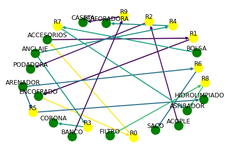

```python
draw_graph(rules, 10)
```

Ahora vamos a estudiar las reglas de cada uno de los clusters

```python
rules_cluster = []
for content in content_cluster:
  te = TransactionEncoder()
  te_ary = te.fit(content).transform(content)
  articulos_general = pd.DataFrame(te_ary, columns=te.columns_)
  frequent_itemsets = apriori(articulos_general, min_support=0.001, use_colnames=True, max_len = 3)
  rules = association_rules(frequent_itemsets, metric="confidence", min_threshold=0.8)
  rules.sort_values(['confidence', 'lift'], ascending = False)
  rules_cluster.append(rules)
```

```python
rules_cluster[0][0:10]
```

|  | antecedents | consequents | antecedent support | consequent support | support | confidence | lift | leverage | conviction |
| --- | --- | --- | --- | --- | --- | --- | --- | --- | --- |
| 0 | (PODADORA) | (ACOPLE) | 0.005319 | 0.005319 | 0.005319 | 1.0 | 188.000000 | 0.005291 | inf |
| 1 | (ACOPLE) | (PODADORA) | 0.005319 | 0.005319 | 0.005319 | 1.0 | 188.000000 | 0.005291 | inf |
| 2 | (ALQUIER) | (ESCARIFICADORA/RESEMBRADORA) | 0.005319 | 0.010638 | 0.005319 | 1.0 | 94.000000 | 0.005263 | inf |
| 3 | (ALQUILERES) | (CASETA) | 0.005319 | 0.069149 | 0.005319 | 1.0 | 14.461538 | 0.004951 | inf |
| 4 | (ANCLAJE) | (CORONA) | 0.026596 | 0.042553 | 0.026596 | 1.0 | 23.500000 | 0.025464 | inf |
| 5 | (ANCLAJE) | (PERFORADORA) | 0.026596 | 0.047872 | 0.026596 | 1.0 | 20.888889 | 0.025323 | inf |
| 6 | (BOLSA) | (ASPIRADOR) | 0.005319 | 0.015957 | 0.005319 | 1.0 | 62.666667 | 0.005234 | inf |
| 7 | (BARREDORA) | (CONSUMIBLES) | 0.005319 | 0.228723 | 0.005319 | 1.0 | 4.372093 | 0.004103 | inf |
| 8 | (BARREDORA) | (MINICARGADORA) | 0.005319 | 0.015957 | 0.005319 | 1.0 | 62.666667 | 0.005234 | inf |
| 9 | (BARREDORA) | (PORTE) | 0.005319 | 0.287234 | 0.005319 | 1.0 | 3.481481 | 0.003791 | inf |

```python
rules_cluster[0].to_excel("/content/drive/MyDrive/Colab Notebooks/Recomendador/cluster0.xlsx", index=True, header=True)
```

```python
rules_cluster[1][0:10]
```

|  | antecedents | consequents | antecedent support | consequent support | support | confidence | lift | leverage | conviction |
| --- | --- | --- | --- | --- | --- | --- | --- | --- | --- |
| 0 | (ACOPLE) | (PODADORA) | 0.010417 | 0.010417 | 0.010417 | 1.0 | 96.000000 | 0.010308 | inf |
| 1 | (PODADORA) | (ACOPLE) | 0.010417 | 0.010417 | 0.010417 | 1.0 | 96.000000 | 0.010308 | inf |
| 2 | (ALQUIER) | (ESCARIFICADORA/RESEMBRADORA) | 0.005208 | 0.010417 | 0.005208 | 1.0 | 96.000000 | 0.005154 | inf |
| 3 | (ROZADORA) | (ALQUILER DISCOS) | 0.005208 | 0.026042 | 0.005208 | 1.0 | 38.400000 | 0.005073 | inf |
| 4 | (ALQUILERES) | (CASETA) | 0.005208 | 0.067708 | 0.005208 | 1.0 | 14.769231 | 0.004856 | inf |
| 5 | (ANCLAJE) | (CORONA) | 0.026042 | 0.041667 | 0.026042 | 1.0 | 24.000000 | 0.024957 | inf |
| 6 | (ANCLAJE) | (PERFORADORA) | 0.026042 | 0.046875 | 0.026042 | 1.0 | 21.333333 | 0.024821 | inf |
| 7 | (BOLSA) | (ASPIRADOR) | 0.005208 | 0.015625 | 0.005208 | 1.0 | 64.000000 | 0.005127 | inf |
| 8 | (BARREDORA) | (CONSUMIBLES) | 0.005208 | 0.239583 | 0.005208 | 1.0 | 4.173913 | 0.003961 | inf |
| 9 | (BARREDORA) | (MINICARGADORA) | 0.005208 | 0.020833 | 0.005208 | 1.0 | 48.000000 | 0.005100 | inf |

```python
rules_cluster[1].to_excel("/content/drive/MyDrive/Colab Notebooks/Recomendador/cluster1.xlsx", index=True, header=True)
```

```python
rules_cluster[2][0:10]
```

|  | antecedents | consequents | antecedent support | consequent support | support | confidence | lift | leverage | conviction |
| --- | --- | --- | --- | --- | --- | --- | --- | --- | --- |
| 0 | (-ALQUILERES) | (CASETA) | 0.020576 | 0.094650 | 0.016461 | 0.800000 | 8.452174 | 0.014513 | 4.526749 |
| 1 | (TROLLEY) | (ALARGADERA) | 0.004115 | 0.012346 | 0.004115 | 1.000000 | 81.000000 | 0.004064 | inf |
| 2 | (AMOLADORA) | (ALQUILER DISCOS) | 0.004115 | 0.028807 | 0.004115 | 1.000000 | 34.714286 | 0.003997 | inf |
| 3 | (CORTADORA) | (ALQUILER DISCOS) | 0.004115 | 0.028807 | 0.004115 | 1.000000 | 34.714286 | 0.003997 | inf |
| 4 | (ROZADORA) | (ALQUILER DISCOS) | 0.008230 | 0.028807 | 0.008230 | 1.000000 | 34.714286 | 0.007993 | inf |
| 5 | (PRENSA) | (ALQUILERES) | 0.004115 | 0.024691 | 0.004115 | 1.000000 | 40.500000 | 0.004014 | inf |
| 6 | (CORONA) | (ANCLAJE) | 0.024691 | 0.020576 | 0.020576 | 0.833333 | 40.500000 | 0.020068 | 5.876543 |
| 7 | (ANCLAJE) | (CORONA) | 0.020576 | 0.024691 | 0.020576 | 1.000000 | 40.500000 | 0.020068 | inf |
| 8 | (ANCLAJE) | (PERFORADORA) | 0.020576 | 0.028807 | 0.020576 | 1.000000 | 34.714286 | 0.019983 | inf |
| 9 | (ARADO) | (MOTOCULTOR) | 0.004115 | 0.004115 | 0.004115 | 1.000000 | 243.000000 | 0.004098 | inf |

```python
rules_cluster[2].to_excel("/content/drive/MyDrive/Colab Notebooks/Recomendador/cluster2.xlsx", index=True, header=True)
```

```python
rules_cluster[3][0:10]
```

|  | antecedents | consequents | antecedent support | consequent support | support | confidence | lift | leverage | conviction |
| --- | --- | --- | --- | --- | --- | --- | --- | --- | --- |
| 0 | (ACOPLE) | (PODADORA) | 0.004566 | 0.009132 | 0.004566 | 1.000000 | 109.500000 | 0.004525 | inf |
| 1 | (AFILADO) | (MOTOSIERRA) | 0.004566 | 0.013699 | 0.004566 | 1.000000 | 73.000000 | 0.004504 | inf |
| 2 | (AMOLADORA) | (ALQUILER DISCOS) | 0.027397 | 0.054795 | 0.022831 | 0.833333 | 15.208333 | 0.021330 | 5.671233 |
| 3 | (ROZADORA) | (ALQUILER DISCOS) | 0.004566 | 0.054795 | 0.004566 | 1.000000 | 18.250000 | 0.004316 | inf |
| 4 | (ANCLAJE) | (CORONA) | 0.036530 | 0.054795 | 0.036530 | 1.000000 | 18.250000 | 0.034528 | inf |
| 5 | (ANCLAJE) | (PERFORADORA) | 0.036530 | 0.054795 | 0.036530 | 1.000000 | 18.250000 | 0.034528 | inf |
| 6 | (LIJADORA) | (ASPIRADOR) | 0.004566 | 0.018265 | 0.004566 | 1.000000 | 54.750000 | 0.004483 | inf |
| 7 | (BANCO) | (CASETA) | 0.009132 | 0.045662 | 0.009132 | 1.000000 | 21.900000 | 0.008715 | inf |
| 8 | (BANCO) | (MESA) | 0.009132 | 0.013699 | 0.009132 | 1.000000 | 73.000000 | 0.009007 | inf |
| 9 | (TUBO) | (BOCA) | 0.004566 | 0.004566 | 0.004566 | 1.000000 | 219.000000 | 0.004545 | inf |

```python
rules_cluster[3].to_excel("/content/drive/MyDrive/Colab Notebooks/Recomendador/cluster3.xlsx", index=True, header=True)
```

```python
rules_cluster[4][0:10]
```

|  | antecedents | consequents | antecedent support | consequent support | support | confidence | lift | leverage | conviction |
| --- | --- | --- | --- | --- | --- | --- | --- | --- | --- |
| 0 | (PUENTE) | (-ALQUILERES) | 0.004255 | 0.021277 | 0.004255 | 1.0 | 47.000000 | 0.004165 | inf |
| 1 | (ACOPLE) | (PODADORA) | 0.008511 | 0.012766 | 0.008511 | 1.0 | 78.333333 | 0.008402 | inf |
| 2 | (ADHESIVO) | (BROCA) | 0.004255 | 0.025532 | 0.004255 | 1.0 | 39.166667 | 0.004147 | inf |
| 3 | (ADHESIVO) | (MARTILLO) | 0.004255 | 0.097872 | 0.004255 | 1.0 | 10.217391 | 0.003839 | inf |
| 4 | (CARCASA) | (AMOLADORA) | 0.004255 | 0.008511 | 0.004255 | 1.0 | 117.500000 | 0.004219 | inf |
| 5 | (ANCLAJE) | (CORONA) | 0.012766 | 0.038298 | 0.012766 | 1.0 | 26.111111 | 0.012277 | inf |
| 6 | (ANCLAJE) | (PERFORADORA) | 0.012766 | 0.051064 | 0.012766 | 1.0 | 19.583333 | 0.012114 | inf |
| 7 | (BOLSA) | (ASPIRADOR) | 0.017021 | 0.038298 | 0.017021 | 1.0 | 26.111111 | 0.016369 | inf |
| 8 | (BANCO) | (CASETA) | 0.008511 | 0.051064 | 0.008511 | 1.0 | 19.583333 | 0.008076 | inf |
| 9 | (TUBO) | (BOCA) | 0.004255 | 0.004255 | 0.004255 | 1.0 | 235.000000 | 0.004237 | inf |

```python
rules_cluster[4].to_excel("/content/drive/MyDrive/Colab Notebooks/Recomendador/cluster4.xlsx", index=True, header=True)
```

```python
rules_cluster[5][0:10]
```

|  | antecedents | consequents | antecedent support | consequent support | support | confidence | lift | leverage | conviction |
| --- | --- | --- | --- | --- | --- | --- | --- | --- | --- |
| 0 | (ACOPLE) | (PODADORA) | 0.004926 | 0.004926 | 0.004926 | 1.000 | 203.000000 | 0.004902 | inf |
| 1 | (PODADORA) | (ACOPLE) | 0.004926 | 0.004926 | 0.004926 | 1.000 | 203.000000 | 0.004902 | inf |
| 2 | (TRONZADORA) | (ALQUILER DISCOS) | 0.009852 | 0.024631 | 0.009852 | 1.000 | 40.600000 | 0.009610 | inf |
| 3 | (COLUMNA) | (ANCLAJE) | 0.004926 | 0.039409 | 0.004926 | 1.000 | 25.375000 | 0.004732 | inf |
| 4 | (ANCLAJE) | (CORONA) | 0.039409 | 0.059113 | 0.034483 | 0.875 | 14.802083 | 0.032153 | 7.527094 |
| 5 | (ANCLAJE) | (PERFORADORA) | 0.039409 | 0.064039 | 0.034483 | 0.875 | 13.663462 | 0.031959 | 7.487685 |
| 6 | (BOLSA) | (ASPIRADOR) | 0.019704 | 0.039409 | 0.019704 | 1.000 | 25.375000 | 0.018928 | inf |
| 7 | (FILTRO) | (ASPIRADOR) | 0.004926 | 0.039409 | 0.004926 | 1.000 | 25.375000 | 0.004732 | inf |
| 8 | (MASCARILLA) | (ASPIRADOR) | 0.004926 | 0.039409 | 0.004926 | 1.000 | 25.375000 | 0.004732 | inf |
| 9 | (BANCO) | (CASETA) | 0.014778 | 0.093596 | 0.014778 | 1.000 | 10.684211 | 0.013395 | inf |

```python
rules_cluster[5].to_excel("/content/drive/MyDrive/Colab Notebooks/Recomendador/cluster5.xlsx", index=True, header=True)
```